# Statistical Analysis

Cover Wu

2021/2/9

## Introduction

This is a Rmarkdown notebook representing primary results of statistical analysis. First, we will briefly introduce the question to be explored. In the field of urban planning, *urban vitality* is an important concept, firstly brought up by Jane Jacobs. Previous research works have developed several metrics to measure the construct. Specifically in this study, the concept refer to the intensity of human activity in a specific urban area, and is treated as between-subject dummy variable: video with high or low vitality is played. We expect that level of urban vitality can significantly predict the subjective experience, and personality factor (specifically, interpersonal trust score in this study) play a role of moderation, illustrated as below.

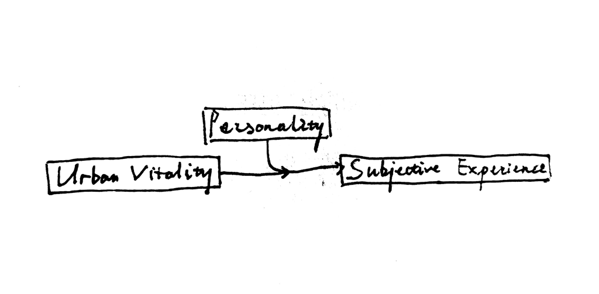

## Exploratory data analysis (EDA)

In this part, exploratory analysis will be performed.

> Descriptive Stat

Firstly, we represent descriptive statistical results. The most important of them are mean and standard deviation. Here, the function **psych::describe()** and **describeBy()** are used to report characteristics of data from both questionnaire and tobii eye-tracker.

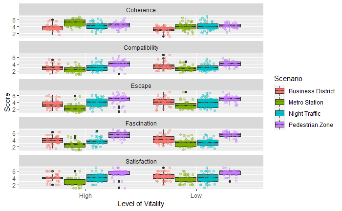

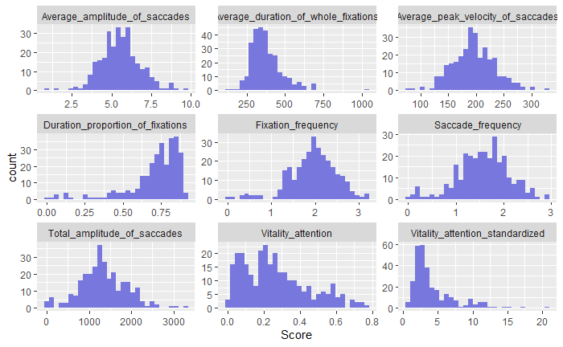

> Reliability

Next, the reliability of the measurement tool should be validated. In the code below, Cronbach’s $\alpha$ coefficient of ITS and four subscale of PRS is computed.

```r
trait_trust %>% select(-Key) %>% psych::alpha()
visit_scale %>% select(Escape1:Escape5) %>% psych::alpha()
visit_scale %>% select(Fascination1:Fascination5) %>% psych::alpha()
visit_scale %>% select(Coherence1:Coherence4) %>% psych::alpha()
visit_scale %>% select(Compatibility1:Compatibility5) %>% psych::alpha()
```

> Validity

For validity, we only concerned the validity of PRS, because we researchers have referred several versions of scale and slightly modified some scale items, yet other scales are used as they originally be. Both constructive validity and criterion validity is considered. Constructive validity is checked with the package **lavaan**, based on the theory of confirmatory factor analaysis.

```r
# constuctive validity: CFA
PRS.model <- 'Escape =~ Escape1 + Escape2 + Escape3 + Escape4 + Escape5
              Fascination =~ Fascination1 + Fascination2 + Fascination3 + Fascination4 + Fascination5
              Coherence =~ Coherence1 + Coherence2 + Coherence3 + Coherence4
              Compatibility =~ Compatibility1 + Compatibility2 + Compatibility3 + Compatibility4 + Compatibility5'
fit <- cfa(PRS.model, data = visit_scale)
summary(fit, fit.measures = TRUE)
```

Criterion validity is analyzed based on theory of factor analysis and canonical correlation. Each participant will watch four street view video, and report subjective vitality (note: different to urban vitality) level for 2 times. By conducting **factor analysis** (FA), we expect estimating *restorative* “factor score” of each scenario from PRS scale for each participant, and these factor scores are predictors. The corresponding criterion is the change of subjective vitality. Then the **canonical correlation** coefficient is computed.

```r
# criterion validity: canonical correlation
# prediction variables are organized in list.
prs_cluster <- visit_scale_score %>% ungroup %>%  select(-RecordedDate, -Satisfaction) %>%
  split(.$Scenario) %>% map(~arrange(., Key) %>% select(-Scenario, -Key))

# criterion
criterion <- vital_subjective_score %>% ungroup %>% select(-(vital_1:vital_7)) %>%
  spread(stage, `Subjective Vitality`) %>% mutate(`Change of Subjective Vitality` = after - before) %>%
  arrange(Key) %>% select(`Change of Subjective Vitality`)

# measure whether the four factors can converge to a single construct: Perceived Restorative.
prs_cluster %>% map(~ fa.parallel(., fa = "both"))
# results show that four factors should be reduced into only 1 dimension except for metro scenario (2 dimension)

# then we start the verification.
# There's one missing value in metro scenario, which should be plugged in.
prs_cluster$`Metro Station` <- prs_cluster$`Metro Station` %>% fill(everything())

# for each scenario, factor analysis is conducted with its factor score computed.
# factor scores in four scenario will be in one record (row), as X with four columns.
fa_scores <- prs_cluster %>% map_df(~factanal(., 1, scores = "Bartlett") %>% .$scores)

# compute the canonical correlation
cancor_result <- cancor(fa_scores, criterion)

# test the corelation coefficient
corcoef.test<-function(r, n, p, q, alpha=0.05){
  m<-length(r); Q<-rep(0, m); lambda <- 1
  for (k in m:1){
    lambda<-lambda*(1-r[k]^2);
    Q[k]<- -log(lambda)
  }
  s<-0; i<-m
  for (k in 1:m){
    Q[k]<- (n-k+1-1/2*(p+q+3)+s)*Q[k]
    chi<-1-pchisq(Q[k], (p-k+1)*(q-k+1))
    if (chi>alpha){
    i<-k-1; break
    }
    s<-s+1/r[k]^2
    }
  i
}
# will return the number of significant coefficient.
corcoef.test(cancor_result$cor, 72, 4, 1)
```

## Producing complete tidy-data and handling the outlier

To analyze the effect hypothesized, we firstly combine all data together.

```r
# put all types of dataframe together to form a complete one:
aggregate_data <- inner_join(personality, visit_scale_score, by = "Key") %>%
  left_join(eye_data, by = c("Key", "Scenario", "Level of Vitality")) %>%
  select(RecordedDate, Key, `Level of Vitality`, Scenario, everything()) %>%
  mutate(`Level of Trust` = if_else(`Interpersonal Trust` >= median(.$`Interpersonal Trust`), "High", "Low") %>% factor()) %>% ungroup()
```

By drawing the graph, we could see the distribution of the data, maybe giving us insights for later analysis.

```r
# exploratory data insight: ggplot to find hidden rules.
# for different scenario and PRS subscale: facet 4 by 4.
ggplot(data = aggregate_data %>% gather(Escape:Compatibility, key = 'variable', value = 'Score'),
       aes(x = `Interpersonal Trust`, y = Score)) +
  geom_point(aes(color = `Level of Vitality`),  alpha = 0.4) +
  geom_smooth(aes(color = `Level of Vitality`), method = "lm") +
  facet_grid(variable ~ Scenario, scales = "free_y")

# for different vitality level and PRS subscale: facet 2 by 4
ggplot(data = aggregate_data %>% gather(Escape:Compatibility, key = 'variable', value = 'Score'),
       aes(x = `Interpersonal Trust`, y = Score)) +
  geom_point(aes(color = `Scenario`),  alpha = 0.4) +
  geom_smooth(aes(color = `Scenario`), method = "lm") +
  facet_grid(variable ~ `Level of Vitality`, scales = "free_y")

# fixation is significant
ggplot(aggregate_data, aes(x = `Interpersonal Trust`, y = Average_duration_of_whole_fixations)) +
  geom_point(aes(color = `Level of Vitality`),  alpha = 0.4) +
  geom_smooth(aes(color = `Level of Vitality`), method = "lm") +
  facet_grid( ~ Scenario, scales = "free_y")
```

[output not shown]

We try to kick the outliers. Eye-tracking metrics seldom follow normal distribution, therefore the criteria of outliers is based on distribution of data rather than standardized *Z*-score.

## Analysis: main hypothesis

Our plan is choosing all dependent variables to form a complete dataset. Then write a function for analyzing simply one column of dependent variable. All analyzing process would be iterated by **purrr::map()** function.

```r
dv_names <- names(dv_columns)
```

[output not shown]

Therefore, a more advanced model is adopted. Hierarchical linear model (HLM) is suitable for analysis with great variance between groups. Here, sceanrio variable is regarded as grouping variable to seperate more variance.

```r
hlm_framework_v2 <- function(test_column){

  # HLM: hierarchical linear model:
  #   one dependent variable is picked up and added to the last column,
  #   to form a complete dataset named "restructured".

  restructured <- aggregate_data_screen %>% select(Key:`Interpersonal Trust`) %>% add_column(var = test_column) %>% rename(Vitality = `Level of Vitality`, Trust = `Interpersonal Trust`)

  # building the model.
  model2 <- lmer(var ~ Vitality * Trust + (1 | Scenario), data = restructured, na.action = na.exclude)

  # return zone
  return(model2)
}
hlm_results <- dv_columns %>% map(hlm_framework_v2)
hlm_results %>% map(summary)
```

```r
fit_folded_batch$`Pedestrian Zone` %>% map(~ map(., summary))
```

```
$Escape
$Escape$fit0

Call:
lm(formula = var ~ Vitality + Trust, data = chosen, na.action = na.exclude)

Residuals:
    Min      1Q  Median      3Q     Max
-3.6344 -0.5558  0.0385  0.6988  2.1108

Coefficients:
            Estimate Std. Error t value Pr(>|t|)
(Intercept)   4.8561     0.1848  26.283   <2e-16 ***
VitalityLow   0.1545     0.2622   0.589    0.558
Trust         0.1366     0.1320   1.034    0.305
---
Signif. codes:  0 ‘***’ 0.001 ‘**’ 0.01 ‘*’ 0.05 ‘.’ 0.1 ‘ ’ 1

Residual standard error: 1.105 on 69 degrees of freedom
Multiple R-squared:  0.01836,   Adjusted R-squared:  -0.01009
F-statistic: 0.6452 on 2 and 69 DF,  p-value: 0.5277


$Escape$fit1

Call:
lm(formula = var ~ Vitality * Trust, data = chosen, na.action = na.exclude)

Residuals:
    Min      1Q  Median      3Q     Max
-3.6131 -0.5855  0.0617  0.6850  2.0617

Coefficients:
                  Estimate Std. Error t value Pr(>|t|)
(Intercept)         4.8470     0.1865  25.985   <2e-16 ***
VitalityLow         0.1561     0.2636   0.592    0.556
Trust               0.2133     0.1970   1.083    0.283
VitalityLow:Trust  -0.1404     0.2666  -0.527    0.600
---
Signif. codes:  0 ‘***’ 0.001 ‘**’ 0.01 ‘*’ 0.05 ‘.’ 0.1 ‘ ’ 1
```

[output cut: 796 more lines]

```
 Min.   :59.00   Min.   :131.2   Min.   :1   Min.   :0.5384   Min.   :0.2421
 1st Qu.:59.25   1st Qu.:131.4   1st Qu.:1   1st Qu.:0.5384   1st Qu.:0.2421
 Median :59.50   Median :131.5   Median :1   Median :0.5384   Median :0.2421
 Mean   :59.50   Mean   :131.5   Mean   :1   Mean   :0.5384   Mean   :0.2421
 3rd Qu.:59.75   3rd Qu.:131.6   3rd Qu.:1   3rd Qu.:0.5384   3rd Qu.:0.2421
 Max.   :60.00   Max.   :131.8   Max.   :1   Max.   :0.5384   Max.   :0.2421
                                 NA's   :1   NA's   :1        NA's   :1
     Pr(>F)
 Min.   :0.6246
 1st Qu.:0.6246
 Median :0.6246
 Mean   :0.6246
 3rd Qu.:0.6246
 Max.   :0.6246
 NA's   :1
```